# Metagenome Analysis

Only ancestral, streptomycin and control treatments are included, unless otherwise stated.

Authors

Niina Smolander

Shane Hogle

# Libraries and functions

Prior to this analysis, the variants have been filtered using Mutect2’s FilterMutectCalls as well as separately for SNPs and INDELs using the following hard filtering factors: SOR, FS, MQ, MQRankSum, ReadPosRankSum, SNP/INDEL clustering (3/35) and SNP/INDEL proximity.

```r
library(tidyverse)
library(Polychrome)
library(withr)
library(fs)
library(compositions)
library(vegan)
library(qvalue)

source("data/input/utils_parallelism.R")
```

# 1) Parallelism at gene level - measurement environment

The analysis done in the section “Parallelism” is repeated here, but the samples are grouped together based on the measurement environment and their history is ignored. Also the t0 samples are not included. This approach is taken as in the community ordination analysis based on the HAMBI abundances the two measurement conditions seem to form separate clusters (https://slhogle.github.io/hambiEvoVEnv/R/strep_only/communities/amplicon_sp_counts/03_ordination_analysis.html)

```r
variants_strep <- read_rds("data/input/variants_strep.rds")

chrom_lengths <- read_tsv("data/input/chrom_lengths.tsv")


degentab <- read_rds("data/input/annotations_codon_degeneracy.rds")

mgvars_filt_mb_ns <- variants_strep %>%
  # exclude intragenic, intergenic, and synonymous mutations. Also exclude
  # fusion functions because these are weird and also rare. Excluding the
  # modifier category also ensures that we filter out any tRNAs with mutations
  filter(!str_detect(EFFECT, "intergenic|intragenic|synonymous|fusion")) %>%
  filter(!str_detect(IMPACT, "MODIFIER"))

muts_by_sp_treat <- mgvars_filt_mb_ns %>%
  mutate(Replicate = paste(str_split_i(home_env, "ome: ", 2),
                           Replicate, sep = "_"),
         replicate = paste(str_split_i(home_env, "ome: ", 2),
                           replicate, sep = "_")) %>%
  dplyr::filter(Timepoint != "t0") %>%
  dplyr::rename(strainID = HAMBI,
                locus_tag = GENE) %>%
  dplyr::select(-c(VAF, Timepoint)) %>%
  group_by(strainID, Measure) %>%
  distinct() %>%
  mutate(groupid = cur_group_id()) %>%
  group_by(groupid, strainID, Measure)


# doing 10000 permutations
# result_sp_treat <- run_full_gene_parallelism_pipeline(muts_by_sp_treat, degentab, 10000)

# Save this for later (saved!)
# write_rds(result_sp_treat, "data/results/annotations_codon_degeneracy_comp_meas.rds")

result_sp_treat <- read_rds("data/results/annotations_codon_degeneracy_comp_meas.rds")

#plot of null and observed
# result_sp_treat$output_simulated_reps %>%
#   ggplot(aes(x = n_reps, y = n, fill = type)) +
#   geom_bar(position = "dodge", stat = "identity") +
#   facet_wrap(Home+strainID ~ Measure) +
#   theme(axis.text.x = element_text(angle = 90, vjust = 0.5, hjust=1))
```

## 1.1) Survival curve plot

Blue line: observed number of genes, Grey line: expected number of genes, Red line: genome-wide significance threshold.

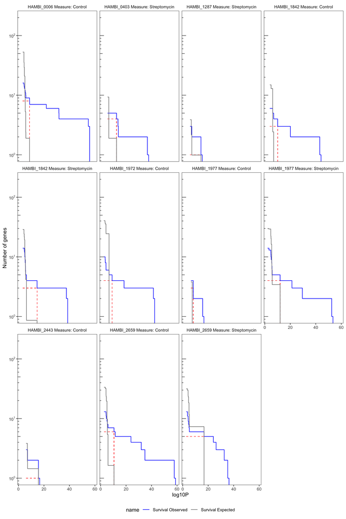

```r
result_sp_treat$output_df2plot %>%
  filter(!is.na(xend)) %>%
  mutate(label = paste(strainID, "Measure:", Measure)) %>%
  ggplot() +
    geom_segment(
      aes(
        x = x,
        y = y,
        xend = xend,
        yend = yend
      ),
      linetype = "dashed",
      linewidth = 0.25, color = "red"
    ) +
    geom_step( aes(x = obs_p, y = value, color = name)) +
    facet_wrap(~ label, ncol = 4) +
    labs(x = "log10P", y = "Number of genes") +
    scale_color_manual(values = c("blue", "grey50")) +
    scale_y_log10(
      breaks = c(1, 10, 100),
      labels = scales::trans_format("log10", scales::math_format(10 ^.x))
    ) +
    annotation_logticks(sides = "l", color = "grey40") +
    coord_cartesian(ylim = c(1, 200)) +
    theme_bw() +
    theme(
      strip.background = element_blank(),
      panel.grid = element_blank(),
      legend.position = "bottom"
    )
```

## 1.2) Significant G scores

```r
t <- result_sp_treat$output_gscore %>%
  filter(pvalue <= 0.05)

knitr::kable(t)
```

| groupid | observed_g_score | pvalue | strainID | Measure |
| --- | --- | --- | --- | --- |
| 1 | 6.171443 | 0.000 | HAMBI_0006 | Control |
| 3 | 7.480148 | 0.000 | HAMBI_0403 | Streptomycin |
| 5 | 7.151826 | 0.000 | HAMBI_1842 | Control |
| 6 | 6.402294 | 0.000 | HAMBI_1842 | Streptomycin |
| 7 | 6.281914 | 0.000 | HAMBI_1972 | Control |
| 9 | 8.099150 | 0.000 | HAMBI_1977 | Control |
| 10 | 6.818021 | 0.000 | HAMBI_1977 | Streptomycin |
| 12 | 7.623093 | 0.017 | HAMBI_2443 | Control |
| 14 | 5.959511 | 0.000 | HAMBI_2659 | Control |
| 15 | 5.788567 | 0.000 | HAMBI_2659 | Streptomycin |

## 1.3) Inspecting individual genes

Filtering out the genes with a too large a number of consecutive mutations and are unlikely to be real mutations.

```r
high_density_genes <- mgvars_filt_mb_ns %>%
  group_by(HAMBI, GENE, replicate, Home, Measure) %>%
  mutate(mutwindox = POS - lag(POS),
         mut_num = n(),
         mut_dens = n()/(max(POS) -  min(POS))) %>%
  ungroup() %>%
  filter(mut_dens != Inf) %>%
  filter(mut_dens > 0.15) %>%
  distinct(GENE) %>%
  pull()

output_gene_table_filt <- result_sp_treat$output_gene_table %>%
  # only genes exceeding the critical pstar value from the survival curves above
  filter(neg_log10P >= pstar) %>%
  # only include genes with at least 3 hits in the same gene or found in more than one replicate.
  filter(observed_hits_n_i >= 3 | n_replicate > 1) %>%
  # filters out the problematic genes above unless the number of replicates detected is 2 or more
  filter(case_when(n_replicate < 2 ~ !(locus_tag %in% high_density_genes),
                   TRUE ~ n_replicate > 1)) %>%
  left_join(degentab, by = join_by(locus_tag, strainID)) %>%
  arrange(locus_tag)

# add some annotation
eggnog <- read_tsv("data/input/HAMBI_all_eggnog_formatted.tsv.xz")

output_gene_table_filt_cog <- left_join(output_gene_table_filt, eggnog) %>%
  rename(prokka_annotation = product) %>%
  relocate(strainID, Measure, COG_category_long, Preferred_name, Description, prokka_annotation)

# write_tsv(output_gene_table_filt_cog, "data/results/parallel_genes_incl_meas_env_only.tsv")
```

```r
rmarkdown::paged_table(output_gene_table_filt)
```

| groupid | locus_tag | neg_log10P | strainID | pstar | nonsyn_sites | observed_hits_n_i | n_replicate | gene_multiplicity_m_i | B_A | B_B | B_C | BS_A | BS_B | BS_C | Anc_A | Anc_B | Anc_C | B_D | Measure | chrom | feature_type | start | end | strand | cds_length | ns_length | f0 | f2 | f3 | … |
| --- | --- | --- | --- | --- | --- | --- | --- | --- | --- | --- | --- | --- | --- | --- | --- | --- | --- | --- | --- | --- | --- | --- | --- | --- | --- | --- | --- | --- | --- | --- |
| 1 | H0006_00502 | 54.821009 | HAMBI_0006 | 8.718660 | 946 | 9 | 9 | 7.5523538 | 1 | 1 | 1 | 1 | 1 | 1 | 1 | 1 | 1 | NA | Control | HAMBI_0006_chrm01_circ | CDS | 582461 | 583603 | + | 1143 | 946 | 735 | 198 | 13 | … |
| 1 | H0006_02725 | 31.699848 | HAMBI_0006 | 8.718660 | 1308 | 6 | 6 | 3.6414509 | 0 | 1 | 0 | 1 | 1 | 1 | 1 | 0 | 1 | NA | Control | HAMBI_0006_chrm01_circ | CDS | 3026200 | 3027846 | + | 1647 | 1308 | 1035 | 260 | 13 | … |
| 1 | H0006_03238 | 54.821009 | HAMBI_0006 | 8.718660 | 575 | 9 | 9 | 12.4252638 | 1 | 1 | 1 | 1 | 1 | 1 | 1 | 1 | 1 | NA | Control | HAMBI_0006_chrm01_circ | CDS | 3598207 | 3598902 | + | 696 | 575 | 448 | 114 | 13 | … |
| 1 | H0006_03606 | 8.718660 | HAMBI_0006 | 8.718660 | 1564 | 2 | 2 | 1.0151359 | 1 | 1 | 0 | 0 | 0 | 0 | 0 | 0 | 0 | NA | Control | HAMBI_0006_chrm01_circ | CDS | 3941492 | 3943390 | - | 1899 | 1564 | 1200 | 335 | 29 | … |
| 1 | H0006_05150 | 31.795158 | HAMBI_0006 | 8.718660 | 1287 | 6 | 6 | 3.7008685 | 1 | 1 | 1 | 1 | 1 | 1 | 0 | 0 | 0 | NA | Control | HAMBI_0006_chrm01_circ | CDS | 5578089 | 5579663 | - | 1575 | 1287 | 1022 | 247 | 18 | … |
| 1 | H0006_05498 | 21.859062 | HAMBI_0006 | 8.718660 | 807 | 4 | 4 | 3.9347524 | 0 | 0 | 0 | 0 | 1 | 1 | 1 | 0 | 1 | NA | Control | HAMBI_0006_chrm01_circ | CDS | 5935698 | 5936705 | - | 1008 | 807 | 619 | 161 | 27 | … |
| 1 | H0006_05646 | 54.821009 | HAMBI_0006 | 8.718660 | 1006 | 9 | 9 | 7.1019152 | 1 | 1 | 1 | 1 | 1 | 1 | 1 | 1 | 1 | NA | Control | HAMBI_0006_chrm01_circ | CDS | 6104417 | 6105688 | + | 1272 | 1006 | 798 | 190 | 18 | … |
| 1 | H0006_05908 | 8.775392 | HAMBI_0006 | 8.718660 | 1520 | 2 | 2 | 1.0445214 | 0 | 1 | 1 | 0 | 0 | 0 | 0 | 0 | 0 | NA | Control | HAMBI_0006_chrm01_circ | CDS | 6403280 | 6405136 | - | 1857 | 1520 | 1167 | 329 | 24 | … |
| 3 | H0403_00507 | 13.669921 | HAMBI_0403 | 12.519504 | 523 | 2 | 2 | 3.0086009 | NA | NA | 0 | NA | NA | NA | 1 | 1 | 0 | NA | Streptomycin | HAMBI_0403_chrm01_circ | CDS | 537205 | 537843 | - | 639 | 523 | 406 | 104 | 13 | … |
| 3 | H0403_02051 | 36.736801 | HAMBI_0403 | 12.519504 | 462 | 5 | 4 | 8.5146011 | NA | NA | 1 | NA | NA | NA | 1 | 2 | 1 | NA | Streptomycin | HAMBI_0403_chrm01_circ | CDS | 2218548 | 2219111 | - | 564 | 462 | 364 | 87 | 11 | … |

[output cut: 29 more lines]

## 1.4) “Venn” table

Which parallel genes were associated with Meas: B, Meas: BS or both? Overall, this approach where samples are grouped just based on their measure environment not necessarily that useful, as for example the gene rsmG is only associated with the meas_B because of the samples that came from streptomycin home environment.

```r
variants_par <- output_gene_table_filt_cog %>%
  mutate(gene_label = ifelse(Preferred_name == "-" | is.na(Preferred_name), prokka_annotation, Preferred_name)) %>%
  mutate(gene_label = ifelse(gene_label == "hypothetical protein", Description, gene_label)) %>%
  mutate(gene_label = ifelse(gene_label == "-" | is.na(gene_label), locus_tag, gene_label)) %>%
  select(HAMBI = strainID, GENE = locus_tag, Measure, B_A:B_D, gene_label)

for_venn <- variants_par %>%
  mutate(gene_label = paste(GENE, gene_label, sep = " - ")) %>%
  select(Measure, gene_label) %>%
  distinct() %>%
  split(., .$Measure) %>%
  map(\(x) unique(x$gene_label))

Meas_B <- for_venn$Control[!(for_venn$Control %in% for_venn$Streptomycin)]
Meas_B_and_BS <- c(for_venn$Control[for_venn$Control %in% for_venn$Streptomycin], rep("",7))
Meas_BS <- c(for_venn$Streptomycin[!(for_venn$Streptomycin %in% for_venn$Control)], rep("",7))

venn_table <- data.frame(Meas_B, Meas_B_and_BS, Meas_BS)
```

```r
knitr::kable(venn_table)
```

| Meas_B | Meas_B_and_BS | Meas_BS |
| --- | --- | --- |
| H0006_00502 - birA | H1842_03187 - PKHD-type hydroxylase | H0403_00507 - Response regulator UvrY |
| H0006_02725 - Periplasmic binding protein domain | H1842_03188 - tonB_2 | H0403_02051 - nfxB |
| H0006_03238 - csiR | H1977_05978 - rsmG | H0403_03909 - flhC |
| H0006_03606 - pedS1 | H2659_00656 - Major fimbrial subunit SMF-1 | H1287_01587 - H1287_01587 |
| H0006_05150 - PFAM PepSY-associated TM helix | H2659_02114 - UDP-N-acetyl-alpha-D-glucosamine C6 dehydratase | H1842_01282 - putative TonB-dependent receptor BfrD |
| H0006_05498 - IV02_12080 | H2659_02217 - Transcriptional activatory protein AadR | H1977_03947 - TRANSCRIPTIONal |
| H0006_05646 - pyrC | H2659_03614 - Vitamin B12 transporter BtuB | H1977_05219 - cellular response to DNA damage stimulus |
| H0006_05908 - butyrate:acetyl-CoA coenzyme A-transferase | H2659_04191 - H2659_04191 | H1977_05315 - rplA |
| H1842_03999 - Vitamin B12 transporter BtuB |  |  |
| H1972_02943 - flhF |  |  |
| H1972_02950 - fliO |  |  |
| H1972_02954 - Flagellar hook-length control protein |  |  |
| H1972_02959 - fliF |  |  |
| H2443_00232 - DnaJ molecular chaperone homology domain |  |  |
| H2659_01498 - H2659_01498 |  |  |

# 2) Parallelism at gene level - Streptomycin

Same analysis as above, but here the data is split into four different groups: [1] No streptomycin at any point (Home:B/Meas:B; ANC/Meas:B), [2] Short streptomycin exposure (Home:B/Meas:BS; ANC/Meas:BS), [3] “Medium” streptomycin exposure (Home:BS/Meas:B) and [4] Long streptomycin exposure (Home:BS/Meas:BS). Timepoint 0 samples are not included.

```r
muts_by_sp_treat <- mgvars_filt_mb_ns %>%
  dplyr::filter(Timepoint != "t0") %>%
  mutate(strep_group = ifelse(Home == "Streptomycin" & Measure == "Streptomycin",
                              "Long",
                              ifelse(Home == "Streptomycin" & Measure == "Control",
                                     "Medium",
                                     ifelse(Measure == "Streptomycin" & (Home == "Control" | Home == "Ancestor"),
                                            "Short",
                                            "None")))) %>%
  mutate(Replicate = paste(str_split_i(home_env, "ome: ", 2),
                           str_split_i(measure_env, "eas: ", 2),
                           Replicate, sep = "_"),
         replicate = paste(str_split_i(home_env, "ome: ", 2),
                           str_split_i(measure_env, "eas: ", 2),
                           replicate, sep = "_")) %>%
  dplyr::rename(strainID = HAMBI,
                locus_tag = GENE) %>%
  dplyr::select(-c(VAF, Timepoint)) %>%
  group_by(strainID, strep_group) %>%
  distinct() %>%
  mutate(groupid = cur_group_id()) %>%
  group_by(groupid, strainID, strep_group)


#doing 10000 permutations
#result_sp_treat <- run_full_gene_parallelism_pipeline(muts_by_sp_treat, degentab, 10000)

#Save this for later (saved!)
#write_rds(result_sp_treat, "data/results/annotations_codon_degeneracy_comp_strep.rds")

result_sp_treat <- read_rds("data/results/annotations_codon_degeneracy_comp_strep.rds")
```

## 2.1) Survival curve plot

Blue line: observed number of genes, Grey line: expected number of genes, Red line: genome-wide significance threshold.

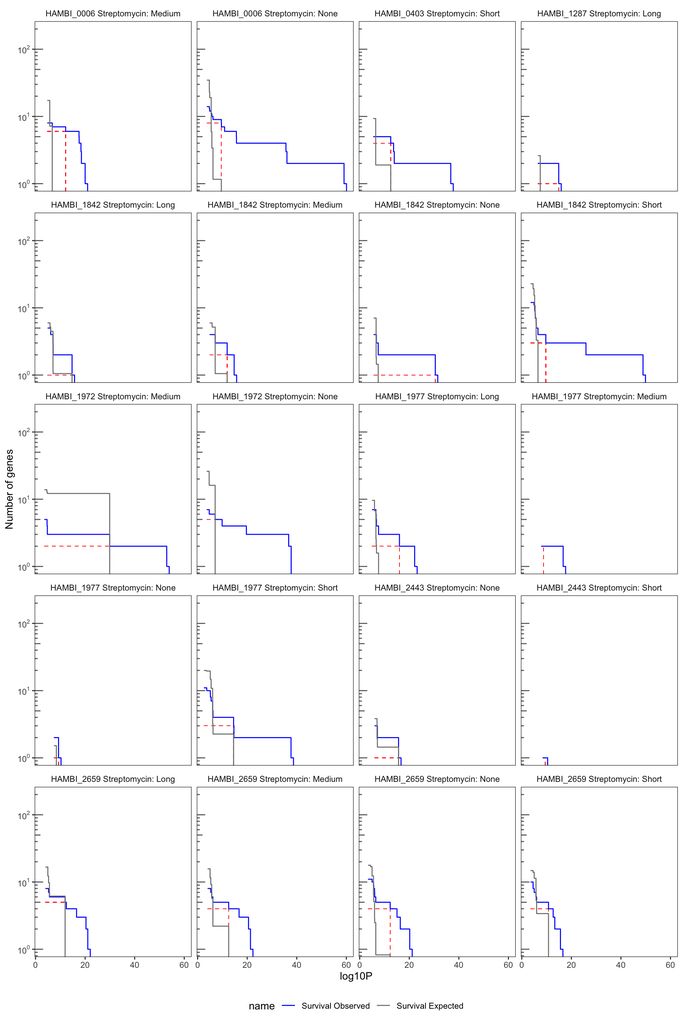

```r
result_sp_treat$output_df2plot %>%
  filter(!is.na(xend)) %>%
  mutate(label = paste(strainID, "Streptomycin:", strep_group)) %>%
  ggplot() +
    geom_segment(
      aes(
        x = x,
        y = y,
        xend = xend,
        yend = yend
      ),
      linetype = "dashed",
      linewidth = 0.25, color = "red"
    ) +
    geom_step( aes(x = obs_p, y = value, color = name)) +
    facet_wrap(~ label, ncol = 4) +
    labs(x = "log10P", y = "Number of genes") +
    scale_color_manual(values = c("blue", "grey50")) +
    scale_y_log10(
      breaks = c(1, 10, 100),
      labels = scales::trans_format("log10", scales::math_format(10 ^.x))
    ) +
    annotation_logticks(sides = "l", color = "grey40") +
    coord_cartesian(ylim = c(1, 200)) +
    theme_bw() +
    theme(
      strip.background = element_blank(),
      panel.grid = element_blank(),
      legend.position = "bottom"
    )
```

## 2.2) Significant G scores

```r
t <- result_sp_treat$output_gscore %>%
  filter(pvalue <= 0.05)

knitr::kable(t)
```

| groupid | observed_g_score | pvalue | strainID | strep_group |
| --- | --- | --- | --- | --- |
| 2 | 6.567938 | 0.0000 | HAMBI_0006 | Medium |
| 3 | 6.161517 | 0.0000 | HAMBI_0006 | None |
| 4 | 7.480148 | 0.0000 | HAMBI_0403 | Short |
| 5 | 7.683207 | 0.0436 | HAMBI_1287 | Long |
| 9 | 7.959357 | 0.0000 | HAMBI_1842 | None |
| 10 | 6.524846 | 0.0000 | HAMBI_1842 | Short |
| 11 | 6.327163 | 0.0000 | HAMBI_1972 | Medium |
| 12 | 6.507136 | 0.0000 | HAMBI_1972 | None |
| 14 | 7.391594 | 0.0000 | HAMBI_1977 | Long |
| 15 | 8.729127 | 0.0002 | HAMBI_1977 | Medium |
| 16 | 8.836713 | 0.0117 | HAMBI_1977 | None |
| 17 | 6.860310 | 0.0000 | HAMBI_1977 | Short |
| 20 | 7.623093 | 0.0167 | HAMBI_2443 | None |
| 21 | 9.438673 | 0.0421 | HAMBI_2443 | Short |
| 22 | 6.168692 | 0.0000 | HAMBI_2659 | Long |
| 23 | 6.208508 | 0.0000 | HAMBI_2659 | Medium |
| 24 | 6.008450 | 0.0000 | HAMBI_2659 | None |

## 2.3) Inspecting individual genes

Filtering out the genes with a too large a number of consecutive mutations and are unlikely to be real mutations.

```r
high_density_genes <- mgvars_filt_mb_ns %>%
  group_by(HAMBI, GENE, replicate, Home, Measure) %>%
  mutate(mutwindox = POS - lag(POS),
         mut_num = n(),
         mut_dens = n()/(max(POS) -  min(POS))) %>%
  ungroup() %>%
  filter(mut_dens != Inf) %>%
  filter(mut_dens > 0.15) %>%
  distinct(GENE) %>%
  pull()

output_gene_table_filt <- result_sp_treat$output_gene_table %>%
  # only genes exceeding the critical pstar value from the survival curves above
  filter(neg_log10P >= pstar) %>%
  # only include genes with at least 3 hits in the same gene or found in more than one replicate.
  filter(observed_hits_n_i >= 3 | n_replicate > 1) %>%
  # filters out the problematic genes above unless the number of replicates detected is 2 or more
  filter(case_when(n_replicate < 2 ~ !(locus_tag %in% high_density_genes),
                   TRUE ~ n_replicate > 1)) %>%
  left_join(degentab, by = join_by(locus_tag, strainID)) %>%
  arrange(locus_tag)

# add some annotation

output_gene_table_filt_cog <- left_join(output_gene_table_filt, eggnog) %>%
  rename(prokka_annotation = product) %>%
  relocate(strainID, strep_group, COG_category_long, Preferred_name, Description, prokka_annotation)

#write_tsv(output_gene_table_filt_cog, "data/results/parallel_genes_incl_strep_group.tsv")
```

```r
rmarkdown::paged_table(output_gene_table_filt)
```

| groupid | locus_tag | neg_log10P | strainID | pstar | nonsyn_sites | observed_hits_n_i | n_replicate | gene_multiplicity_m_i | BS_BS_A | BS_B_A | BS_B_B | BS_B_C | B_B_A | B_B_B | B_B_C | Anc_B_A | Anc_B_B | Anc_B_C | B_BS_C | Anc_BS_A | Anc_BS_B | Anc_BS_C | BS_BS_C | B_BS_D | BS_BS_B | B_BS_B | strep_group | chrom | feature_type | … |
| --- | --- | --- | --- | --- | --- | --- | --- | --- | --- | --- | --- | --- | --- | --- | --- | --- | --- | --- | --- | --- | --- | --- | --- | --- | --- | --- | --- | --- | --- | --- |
| 2 | H0006_00502 | 18.511661 | HAMBI_0006 | 12.157847 | 946 | 3 | 3 | 2.5174513 | NA | 1 | 1 | 1 | NA | NA | NA | NA | NA | NA | NA | NA | NA | NA | NA | NA | NA | NA | Medium | HAMBI_0006_chrm01_circ | CDS | … |
| 3 | H0006_00502 | 36.043653 | HAMBI_0006 | 9.562104 | 946 | 6 | 6 | 5.0349025 | NA | NA | NA | NA | 1 | 1 | 1 | 1 | 1 | 1 | NA | NA | NA | NA | NA | NA | NA | NA | None | HAMBI_0006_chrm01_circ | CDS | … |
| 2 | H0006_02725 | 17.540716 | HAMBI_0006 | 12.157847 | 1308 | 3 | 3 | 1.8207255 | NA | 1 | 1 | 1 | NA | NA | NA | NA | NA | NA | NA | NA | NA | NA | NA | NA | NA | NA | Medium | HAMBI_0006_chrm01_circ | CDS | … |
| 3 | H0006_02725 | 15.627002 | HAMBI_0006 | 9.562104 | 1308 | 3 | 3 | 1.8207255 | NA | NA | NA | NA | 0 | 1 | 0 | 1 | 0 | 1 | NA | NA | NA | NA | NA | NA | NA | NA | None | HAMBI_0006_chrm01_circ | CDS | … |
| 2 | H0006_03238 | 20.004160 | HAMBI_0006 | 12.157847 | 575 | 3 | 3 | 4.1417546 | NA | 1 | 1 | 1 | NA | NA | NA | NA | NA | NA | NA | NA | NA | NA | NA | NA | NA | NA | Medium | HAMBI_0006_chrm01_circ | CDS | … |
| 3 | H0006_03238 | 59.069504 | HAMBI_0006 | 9.562104 | 575 | 6 | 6 | 8.2835092 | NA | NA | NA | NA | 1 | 1 | 1 | 1 | 1 | 1 | NA | NA | NA | NA | NA | NA | NA | NA | None | HAMBI_0006_chrm01_circ | CDS | … |
| 3 | H0006_03606 | 9.562104 | HAMBI_0006 | 9.562104 | 1564 | 2 | 2 | 1.0151359 | NA | NA | NA | NA | 1 | 1 | 0 | 0 | 0 | 0 | NA | NA | NA | NA | NA | NA | NA | NA | None | HAMBI_0006_chrm01_circ | CDS | … |
| 2 | H0006_05150 | 17.589208 | HAMBI_0006 | 12.157847 | 1287 | 3 | 3 | 1.8504343 | NA | 1 | 1 | 1 | NA | NA | NA | NA | NA | NA | NA | NA | NA | NA | NA | NA | NA | NA | Medium | HAMBI_0006_chrm01_circ | CDS | … |
| 3 | H0006_05150 | 15.675438 | HAMBI_0006 | 9.562104 | 1287 | 3 | 3 | 1.8504343 | NA | NA | NA | NA | 1 | 1 | 1 | 0 | 0 | 0 | NA | NA | NA | NA | NA | NA | NA | NA | None | HAMBI_0006_chrm01_circ | CDS | … |
| 2 | H0006_05498 | 12.157847 | HAMBI_0006 | 12.157847 | 807 | 2 | 2 | 1.9673762 | NA | 0 | 1 | 1 | NA | NA | NA | NA | NA | NA | NA | NA | NA | NA | NA | NA | NA | NA | Medium | HAMBI_0006_chrm01_circ | CDS | … |

[output cut: 42 more lines]

## 2.4) UpSet plot and table of parallel genes

Plot key: None: No streptomycin at any point (Home:B/Meas:B; ANC/Meas:B); Short: Short streptomycin exposure (Home:B/Meas:BS; ANC/Meas:BS); Medium: Home:BS/Meas:B; Long: Home:BS/Meas:BS.

```r
variants_par <- output_gene_table_filt_cog %>%
  mutate(gene_label = ifelse(Preferred_name == "-" | is.na(Preferred_name), prokka_annotation, Preferred_name)) %>%
  mutate(gene_label = ifelse(gene_label == "hypothetical protein", Description, gene_label)) %>%
  mutate(gene_label = ifelse(gene_label == "-" | is.na(gene_label), locus_tag, gene_label)) %>%
  select(HAMBI = strainID, GENE = locus_tag, gene_label, strep_group)

venn_prep <- variants_par %>%
  mutate(gene_label = paste(GENE, gene_label, sep = " - ")) %>%
  select(gene_label, strep_group) %>%
  distinct()

venn_prep <- split(venn_prep, venn_prep$strep_group) %>%
  map(\(x) unique(x$gene_label))

p <- ggVennDiagram::ggVennDiagram(venn_prep, force_upset = T)


venn_table <- p$plotlist[[2]]$data %>%
  arrange(id) %>%
  select(name, item) %>%
  mutate(item = str_remove_all(item, "c\\(|\\)")) %>%
  separate_longer_delim(item, ",") %>%
  mutate(item = str_trim(item),
         item = str_remove_all(item, "\""),
         item = str_remove_all(item, "character\\(0")) %>%
  group_by(name) %>%
  mutate(number = 1:n()) %>%
  pivot_wider(names_from = name, values_from = item) %>%
  select(-number)
```

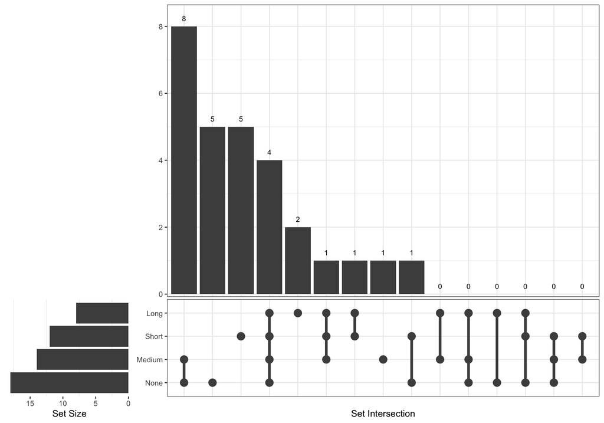

```r
p
```

```r
rmarkdown::paged_table(venn_table)
```

| Medium/None | None | Short | Long/Medium/None/Short | Long | Long/Medium/Short | Long/Short | Medium | None/Short | Long/Medium | Long/Medium/None | Long/None | Long/None/Short | Medium/None/Short | Medium/Short |
| --- | --- | --- | --- | --- | --- | --- | --- | --- | --- | --- | --- | --- | --- | --- |
| H0006_00502 - birA | H0006_03606 - pedS1 | H0403_00507 - Response regulator UvrY | H2659_00656 - Major fimbrial subunit SMF-1 | H1287_01587 - H1287_01587 | H1977_05978 - rsmG | H1977_05219 - cellular response to DNA damage stimulus | H1842_03999 - Vitamin B12 transporter BtuB | H1842_03187 - PKHD-type hydroxylase |  |  |  |  |  |  |
| H0006_02725 - Periplasmic binding protein domain | H0006_05908 - butyrate:acetyl-CoA coenzyme A-transferase | H0403_02051 - nfxB | H2659_02114 - UDP-N-acetyl-alpha-D-glucosamine C6 dehydratase | H2659_04191 - H2659_04191 | NA | NA | NA | NA | NA | NA | NA | NA | NA | NA |
| H0006_03238 - csiR | H1972_02943 - flhF | H0403_03909 - flhC | H2659_02217 - Transcriptional activatory protein AadR | NA | NA | NA | NA | NA | NA | NA | NA | NA | NA | NA |
| H0006_05150 - PFAM PepSY-associated TM helix | H1972_02950 - fliO | H1842_01282 - putative TonB-dependent receptor BfrD | H2659_03614 - Vitamin B12 transporter BtuB | NA | NA | NA | NA | NA | NA | NA | NA | NA | NA | NA |
| H0006_05498 - IV02_12080 | H2443_00232 - DnaJ molecular chaperone homology domain | H1842_03188 - tonB_2 | NA | NA | NA | NA | NA | NA | NA | NA | NA | NA | NA | NA |
| H0006_05646 - pyrC | NA | NA | NA | NA | NA | NA | NA | NA | NA | NA | NA | NA | NA | NA |
| H1972_02954 - Flagellar hook-length control protein | NA | NA | NA | NA | NA | NA | NA | NA | NA | NA | NA | NA | NA | NA |
| H1972_02959 - fliF | NA | NA | NA | NA | NA | NA | NA | NA | NA | NA | NA | NA | NA | NA |